# Fst

Claudius

17/12/2016

# Unfolded SAF’s

I have created unfolded SAF’s and used an unfolded 2D-SFS to calculate posterior expectations of per-site $F_{ST}$. `realSFS` allows the calculation from two different formula’s. One according to Reynolds (Fumagalli et al. 2013) and the other accroding to Hudson/Bhatia (Bhatia et al. 2013).

```r
bhatia = read.delim("EryPar.Bhatia.fst.tab", header=F)
names(bhatia) = c("contig", "pos", "Hb.minus.Hw", "Hb")
nrow(bhatia)
```

```
## [1] 1629161
```

```r
str(bhatia)
```

```
## 'data.frame':    1629161 obs. of  4 variables:
##  $ contig     : Factor w/ 32706 levels "Contig_10001",..: 1 1 1 1 1 1 1 1 1 1 ...
##  $ pos        : int  8 9 10 11 12 13 14 15 16 17 ...
##  $ Hb.minus.Hw: num  0 0 0 0 0 0 0 0 0 0 ...
##  $ Hb         : num  4e-06 4e-06 4e-06 6e-06 4e-06 4e-06 4e-06 4e-06 6e-06 4e-06 ...
```

```r
reynolds = read.delim("EryPar.Reynolds.fst.tab", header=F)
names(reynolds) = c("contig", "pos", "a", "a.plus.b")
head(reynolds)
```

```
##         contig pos a a.plus.b
## 1 Contig_10001   8 0    4e-06
## 2 Contig_10001   9 0    4e-06
## 3 Contig_10001  10 0    4e-06
## 4 Contig_10001  11 0    6e-06
## 5 Contig_10001  12 0    4e-06
## 6 Contig_10001  13 0    4e-06
```

## Global average $F_{ST}$ between ERY and PAR

```r
( Fst.bhatia.global = sum(bhatia[["Hb.minus.Hw"]])/sum(bhatia[["Hb"]]) )
```

```
## [1] 0.2982697
```

```r
nrow(bhatia)
```

```
## [1] 1629161
```

```r
( Fst.reynolds.global = sum(reynolds$a)/sum(reynolds[["a.plus.b"]]) )
```

```
## [1] 0.3081538
```

```r
nrow(reynolds)
```

```
## [1] 1629161
```

Both formulas provide very similar estimates. The estimates are taken over 1629161 sites. Reynolds $F_{ST}$ is weighting by sample size, which I think is an undesirable property (i. e. a change in sample size, that does not change the estimate of sample allele frequencies can change the estimate of $F_{ST}$).

## $F_{ST}$ by contig

In the following, I want to collapse the data set, by keeping only the average $F_{ST}$ per contig.

### Bhatia

```r
Fst.by.contig = aggregate(cbind(Hb.minus.Hw, Hb) ~ contig,
                          data=bhatia,
                          sum
                            )
Fst.by.contig = cbind(Fst.by.contig, FST=Fst.by.contig[,2]/Fst.by.contig[,3])
#
contig.lengths = tapply(bhatia$contig, bhatia$contig, length)
head(names(contig.lengths))
```

```
## [1] "Contig_10001"  "Contig_100013" "Contig_100028" "Contig_10006"
## [5] "Contig_100060" "Contig_100072"
```

```r
head(Fst.by.contig)
```

```
##          contig Hb.minus.Hw       Hb         FST
## 1  Contig_10001   -0.002809 0.245646 -0.01143515
## 2 Contig_100013   -0.002809 0.245646 -0.01143515
## 3 Contig_100028    0.096076 1.035791  0.09275616
## 4  Contig_10006    0.203802 0.721350  0.28252859
## 5 Contig_100060    0.020828 0.281761  0.07392081
## 6 Contig_100072    0.001328 0.056703  0.02342028
```

```r
tail(names(contig.lengths))
```

```
## [1] "Contig_99953" "Contig_99958" "Contig_99972" "Contig_99976"
## [5] "Contig_99988" "Contig_99997"
```

```r
tail(Fst.by.contig)
```

```
##             contig Hb.minus.Hw       Hb        FST
## 32701 Contig_99953    0.072278 0.398611 0.18132465
## 32702 Contig_99958    1.321885 1.638132 0.80694657
## 32703 Contig_99972    0.000469 0.016771 0.02796494
## 32704 Contig_99976    0.065525 0.903353 0.07253532
## 32705 Contig_99988    0.746464 0.874866 0.85323238
## 32706 Contig_99997    0.034389 0.797525 0.04311965
```

```r
Fst.by.contig = cbind(Fst.by.contig, length=contig.lengths)
head(Fst.by.contig)
```

```
##                      contig Hb.minus.Hw       Hb         FST length
## Contig_10001   Contig_10001   -0.002809 0.245646 -0.01143515    132
## Contig_100013 Contig_100013   -0.002809 0.245646 -0.01143515    132
## Contig_100028 Contig_100028    0.096076 1.035791  0.09275616     72
## Contig_10006   Contig_10006    0.203802 0.721350  0.28252859     39
## Contig_100060 Contig_100060    0.020828 0.281761  0.07392081     67
## Contig_100072 Contig_100072    0.001328 0.056703  0.02342028     36
```

```r
#
( sum(Fst.by.contig$Hb.minus.Hw)/sum(Fst.by.contig$Hb) )
```

```
## [1] 0.2982697
```

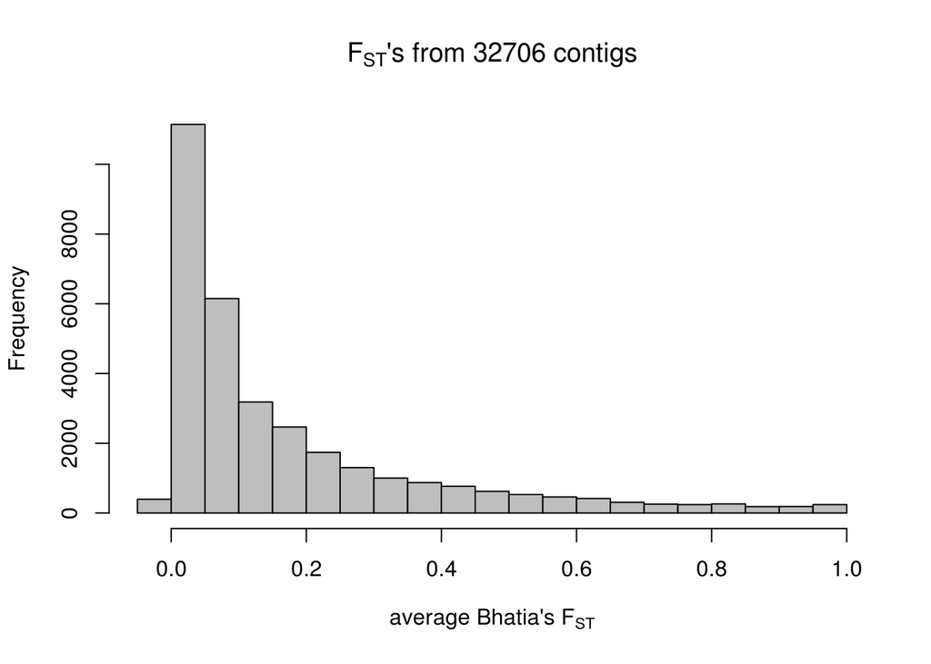

```r
hist(Fst.by.contig$FST, xlab=expression(paste("average Bhatia's ", F[ST])),
     main=bquote(paste(F[ST], "'s from ", .(nrow(Fst.by.contig)), " contigs")),
     col="grey"
     )
```

```r
# proportion of loci with Fst greater than average Fst:
gtAvgFst = sum(Fst.by.contig$FST > Fst.bhatia.global)/length(Fst.by.contig$FST)
```

As expected, the majority of the contigs are very little differentiated between the two populations, but 20% of loci have $F_{ST}$ greater than the global average.

#### Bootstrap

It would be nice to get an estimate of uncertainty in the estimate of the global $F_{ST}$. There are two major sources of variation that influence this estimate:

1. sampling variation of individuals from populations
2. sampling variation of loci from the genome

In order to approximate the first source of variation, I could bootstrap resample individuals, but that requires many re-stimations of SAF’s which will be quite compute and data intensive. I am therefore only going to approximate the second source of variation for the moment.

```r
library(dplyr) # for 'sample_n'
library(parallel) # for 'mclapply'
#
boot = function(x){
  # creates bootstrap resamples of the rows in Fst.by.contig
  # and returns the global Fst from that
  rs = sample_n(Fst.by.contig, size=nrow(Fst.by.contig), replace=TRUE)
  sum(rs$Hb.minus.Hw)/sum(rs$Hb)
  }
#
# serial:
#boot.resample.Fst.by.contig = replicate(10000, boot())
# parallel:
startTime = proc.time()
boot.resample.Fst.by.contig = vector("double", length=10000)
boot.resample.Fst.by.contig= simplify2array(
  mclapply(1:length(boot.resample.Fst.by.contig),
          FUN=boot,
          mc.cores=20
           )
  )
stopTime = proc.time()
elapsedTime = stopTime - startTime
show(elapsedTime)
```

```
##    user  system elapsed
## 461.781   5.925  25.543
```

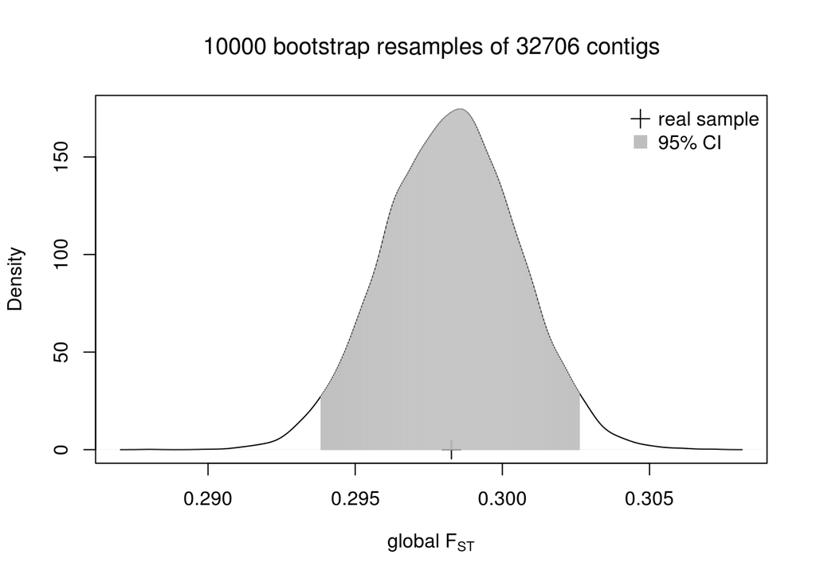

```r
#
d = density(boot.resample.Fst.by.contig)
plot(d,
     xlab=expression(paste("global ", F[ST])),
     main=bquote(paste(.(length(boot.resample.Fst.by.contig)),
                       " bootstrap resamples of ", .(nrow(Fst.by.contig)),
                       " contigs"
                       )
                 )
     )
points(c(Fst.bhatia.global), c(0), pch=3, cex=1.5)
CI95 = quantile(boot.resample.Fst.by.contig, probs=c(.025, .975))
lines(d$x[d$x>CI95[1] & d$x<CI95[2]],
      d$y[d$x>CI95[1] & d$x<CI95[2]],
      type="h",
      col="grey")
legend("topright", legend=c("real sample", "95% CI"), pch=c(3,15), pt.cex=1.5, col=c("black", "grey"), bty="n")
```

### Reynolds

```r
Fst.reynolds.by.contig = aggregate(cbind(a, a.plus.b) ~ contig,
                          data=reynolds,
                          sum
                            )
Fst.reynolds.by.contig = cbind(Fst.reynolds.by.contig, FST=Fst.reynolds.by.contig[,2]/Fst.reynolds.by.contig[,3])
head(Fst.reynolds.by.contig)
```

```
##          contig        a a.plus.b         FST
## 1  Contig_10001 0.000684 0.245646 0.002784495
## 2 Contig_100013 0.000684 0.245646 0.002784495
## 3 Contig_100028 0.109325 1.035791 0.105547355
## 4  Contig_10006 0.211104 0.721350 0.292651279
## 5 Contig_100060 0.024513 0.281761 0.086999265
## 6 Contig_100072 0.002116 0.056703 0.037317250
```

```r
( sum(Fst.reynolds.by.contig$a)/sum(Fst.reynolds.by.contig$a.plus.b) )
```

```
## [1] 0.3081538
```

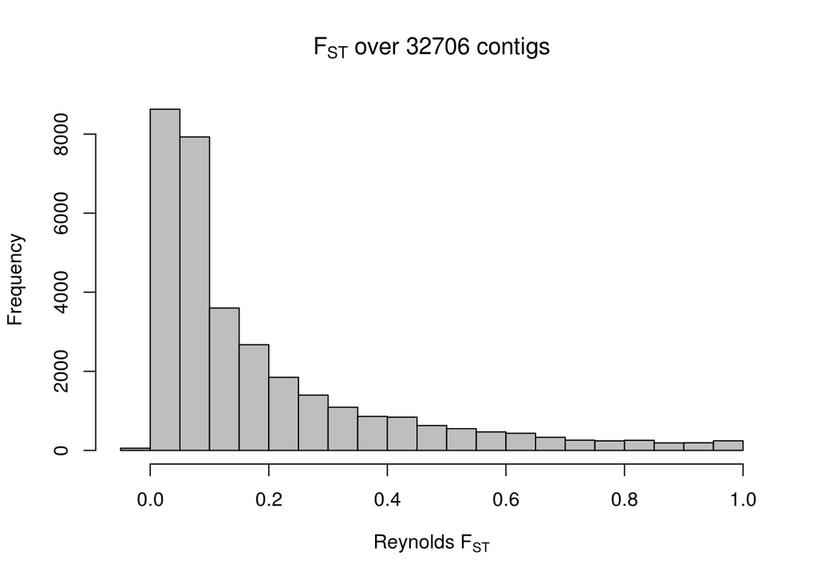

```r
hist(Fst.reynolds.by.contig$FST, xlab=expression(paste("Reynolds ", F[ST])),
     main=bquote(paste(F[ST], " over ", .(nrow(Fst.reynolds.by.contig)), " contigs")),
     col="grey"
     )
```

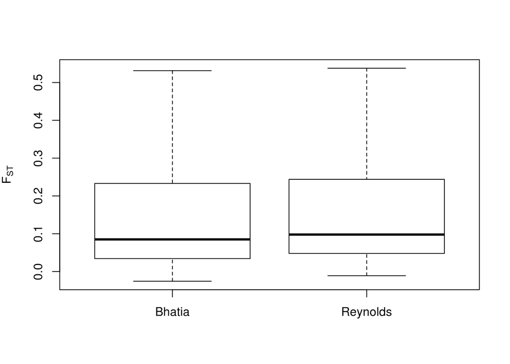

```r
boxplot(data.frame(Bhatia=Fst.by.contig$FST, Reynolds=Fst.reynolds.by.contig$FST), outline=FALSE, ylab=expression(F[ST]))
```

Reynolds’ formula produces slightly higher $F_{ST}$ values.

### 2D-SFS

```r
sfs2d = scan("/data3/claudius/Big_Data/ANGSD/FST/EryPar.unfolded.2dsfs")
sfs2d = matrix(sfs2d, nrow=37, ncol=37) # rows should be PAR, columns should be ERY
sfs2d[1,1] = 0
```

```r
library(fields)
```

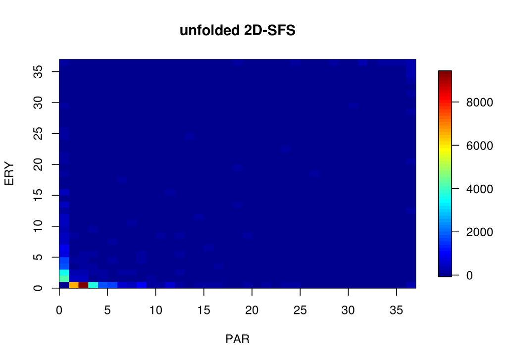

```r
# rows in the matrix are on the x-axis, columns are on the y-axis:
image.plot(0:37, 0:37, sfs2d, xlab="PAR", ylab="ERY", main="unfolded 2D-SFS")
```

## Permutation test of global $F_{ST}$

I have randomly permutated the 36 individuals into a population 1 and population 2. I have then estimated SAF’s, 2D-SFS’s and $F_{ST}$ for each permutation.

```r
# only needs to be run once:
# fst.tabs = list.files("Bootstrap/", "*tab")
# perm = function(x){
#   bhatia = read.delim(fst.tabs[x], header=F)
#   return( sum(bhatia[,3])/sum(bhatia[,4]) )
# }
# startTime = proc.time()
# perm.fst = vector("double", len=length(fst.tabs))
# perm.fst = simplify2array(
#   mclapply(1:length(perm.fst),
#           FUN=perm,
#           mc.cores=20
#            )
#   )
# stopTime = proc.time()
# elapsedTime = stopTime - startTime
# show(elapsedTime)
# save(perm.fst, file="Bootstrapperm.global.fst.RData")
```

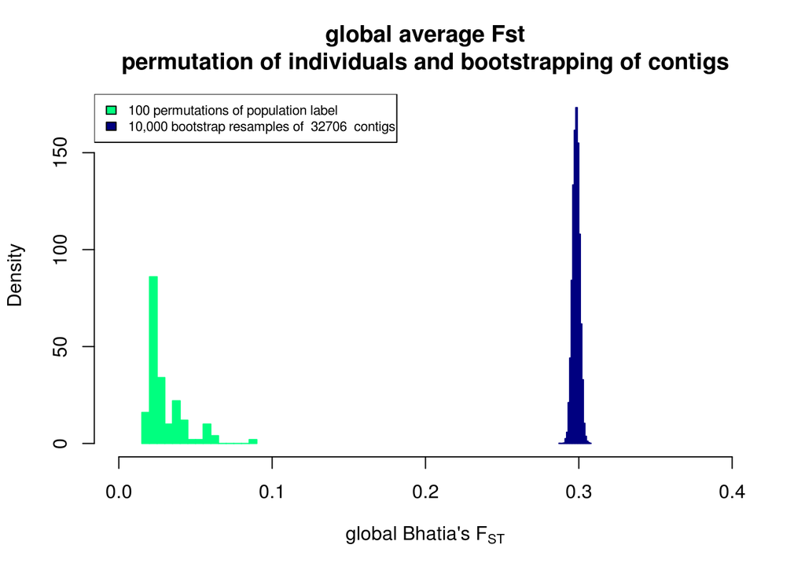

```r
load("Bootstrap/perm.global.fst.RData")
hist(boot.resample.Fst.by.contig,
     border="navyblue", col="navyblue",
     freq=FALSE,
     xlim=c(0,.4),
     main="global average Fst\npermutation of individuals and bootstrapping of contigs",
     xlab=expression(paste("global Bhatia's ", F[ST]))
     )
hist(perm.fst, breaks=20, border="springgreen", col="springgreen",
     add=TRUE,
     freq=FALSE
     )
legend("topleft",
       legend=c("100 permutations of population label",
                paste("10,000 bootstrap resamples of ", nrow(Fst.by.contig), " contigs")),
       col=c("springgreen", "navyblue"),
       cex=.7,
       fill=c("springgreen", "navyblue")
      )
```

## $F_{ST}$ by ascertainment class

I have calculated ML estimates of minor allele frequencies for each population, ERY and PAR. I have then created joint tables of each MAF file with `/data3/claudius/Big_Data/ANGSD/FST/EryPar.Bhatia.fst.tab`. I have now MAF’s and $F_{ST}$ for 1,513,856 sites in ERY and 1,496,271 sites in PAR.

### Ascertainment in PAR

```r
pp = pipe("cut -f1,2,7,8,11,12 /data3/claudius/Big_Data/ANGSD/FST/MAFs/PAR/PAR.mafs.withFST", open="r")
par.mafs.withFST = read.delim(pp, header=F)
names(par.mafs.withFST) = c("contig", "pos", "MAF", "nind", "Hb.minus.Hw", "Hb")
head(par.mafs.withFST)
```

```
##      contig pos MAF nind Hb.minus.Hw       Hb
## 1 Contig_16   8   0    4     2.0e-06 0.000120
## 2 Contig_16   9   0    4     2.0e-06 0.000120
## 3 Contig_16  10   0    4     2.0e-06 0.000120
## 4 Contig_16  11   0    4     1.4e-05 0.000526
## 5 Contig_16  12   0    4     1.0e-05 0.000353
## 6 Contig_16  13   0    4     2.0e-06 0.000120
```

```r
n = 18 # 18 individuals
global.fst.by.PAR.ascert = vector("double", n-1)
j = 0
for(i in 1:(n-1)){
  #print(i)
  j = j+1
  tab = par.mafs.withFST[par.mafs.withFST$MAF > i/(2*n) & par.mafs.withFST$MAF < (i+1)/(2*n),]
  global.fst.by.PAR.ascert[j] = sum(tab["Hb.minus.Hw"])/sum(tab["Hb"])
}
```

### Ascertainment in ERY

```r
pp = pipe("cut -f1,2,7,8,11,12 /data3/claudius/Big_Data/ANGSD/FST/MAFs/ERY/ERY.mafs.withFST", open="r")
ery.mafs.withFST = read.delim(pp, header=F)
names(ery.mafs.withFST) = c("contig", "pos", "MAF", "nind", "Hb.minus.Hw", "Hb")
head(ery.mafs.withFST)
```

```
##      contig pos MAF nind Hb.minus.Hw       Hb
## 1 Contig_16   8   0   16     2.0e-06 0.000120
## 2 Contig_16   9   0   16     2.0e-06 0.000120
## 3 Contig_16  10   0   16     2.0e-06 0.000120
## 4 Contig_16  11   0   16     1.4e-05 0.000526
## 5 Contig_16  12   0   16     1.0e-05 0.000353
## 6 Contig_16  13   0   16     2.0e-06 0.000120
```

```r
n = 18 # 18 individuals
global.fst.by.ERY.ascert = vector("double", n-1)
j = 0
for(i in 1:(n-1)){
  #print(i)
  j = j+1
  tab = ery.mafs.withFST[ery.mafs.withFST$MAF > i/(2*n) & ery.mafs.withFST$MAF < (i+1)/(2*n),]
  global.fst.by.ERY.ascert[j] = sum(tab["Hb.minus.Hw"])/sum(tab["Hb"])
}
```

I am trying to produce a plot analogous to figure 1 in (Bhatia et al. 2013).

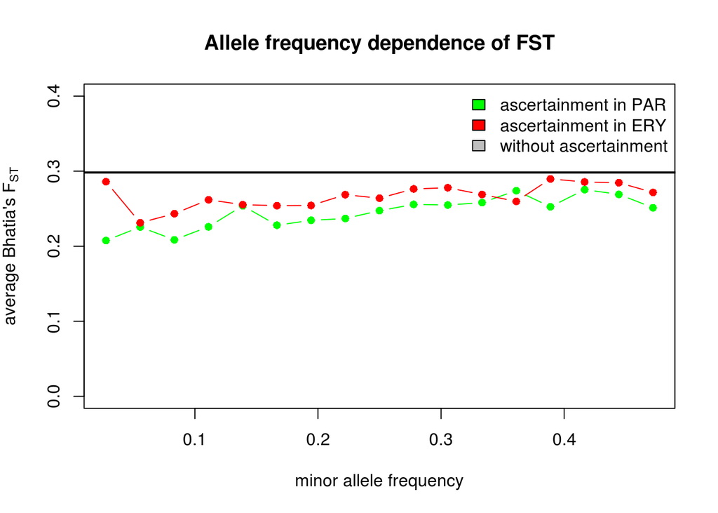

```r
plot(1:(n-1)/(2*n), global.fst.by.PAR.ascert,
     ylim=c(0,.4), ylab=expression(paste("average Bhatia's ", F[ST])),
     xlab="minor allele frequency",
     pch=16, col="green",
     type="b",
     main="Allele frequency dependence of FST"
     )
lines(1:(n-1)/(2*n), global.fst.by.ERY.ascert,
     ylim=c(0,1), ylab=expression(paste("average Bhatia's ", F[ST])),
     xlab="minor allele frequency",
     pch=16, col="red",
     type="b"
     )
legend("topright",
       legend=c("ascertainment in PAR", "ascertainment in ERY", "without ascertainment"),
       col=c("green", "red", "grey"),
       fill=c("green", "red", "grey"),
       bty="n"
       )
abline(h=Fst.bhatia.global, lwd=2)
```

## $F_{ST}$ ddistributions

```r
# ascertaining by ML estimate of minor allele frequency:
ery.snps = ery.mafs.withFST[ery.mafs.withFST$MAF>1/(2*n),]
par.snps = par.mafs.withFST[par.mafs.withFST$MAF>1/(2*n),] # not edible
nrow(ery.snps)
```

```
## [1] 44573
```

```r
nrow(par.snps)
```

```
## [1] 49976
```

```r
head(ery.snps, n=20)
```

```
##         contig pos      MAF nind Hb.minus.Hw       Hb
## 24   Contig_16  31 0.027793   16    0.000002 0.000120
## 94   Contig_40  21 0.140206   14    0.005965 0.159682
## 96   Contig_40  23 0.094817   14    0.000711 0.085768
## 100  Contig_40  27 0.140242   14    0.715508 0.846163
## 115  Contig_40  42 0.139507   14    0.017263 0.136076
## 127  Contig_46  14 0.219184   13    0.000002 0.000117
## 147  Contig_46  34 0.035605   13    0.000002 0.000117
## 148  Contig_46  35 0.466938   13    0.000002 0.000117
## 199  Contig_99   8 0.077599   13    0.000001 0.000072
## 212  Contig_99  21 0.041869   13    0.000000 0.000046
## 333 Contig_186  25 0.427314   15    0.000003 0.000171
## 334 Contig_186  26 0.427225   15    0.000003 0.000171
## 415 Contig_219  27 0.029496   17    0.000082 0.030115
## 537 Contig_270  29 0.052673   11    0.000012 0.000393
## 604 Contig_299  16 0.052086   15    0.000000 0.000028
## 611 Contig_299  23 0.146128   15    0.000000 0.000036
## 614 Contig_299  26 0.199966   15    0.000000 0.000028
## 655 Contig_302  27 0.163362   12    0.002195 0.323024
## 679 Contig_308  11 0.171932   15    0.018640 0.133295
## 686 Contig_308  18 0.040460   15    0.000044 0.017899
```

Parallelus seems to have more SNP’s than erythropus.

### Ascertained in *erythropus*

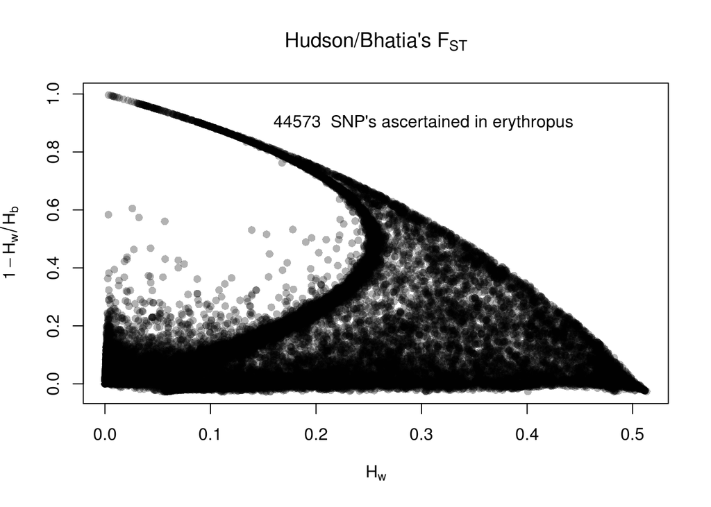

```r
plot(-1*(ery.snps$Hb.minus.Hw-ery.snps$Hb), ery.snps$Hb.minus.Hw/ery.snps$Hb,
     xlab=expression(H[w]),
     ylab=expression(1-H[w]/H[b]),
     pch=16,
     col=gray(level=0, alpha=.3),
     main=expression(paste("Hudson/Bhatia's ", F[ST]))
    )
text(x=.15, y=.9, labels=paste(nrow(ery.snps), " SNP's ascertained in erythropus"), pos=4)
```

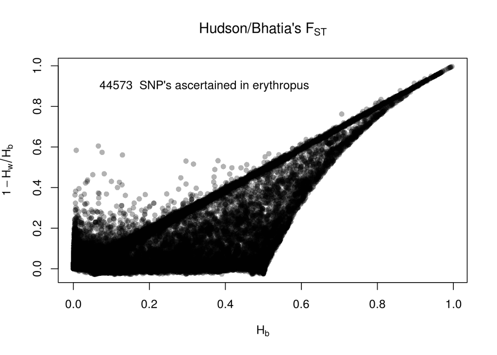

```r
plot(ery.snps$Hb, ery.snps$Hb.minus.Hw/ery.snps$Hb,
     xlab=expression(H[b]),
     ylab=expression(1-H[w]/H[b]),
     pch=16,
     col=gray(level=0, alpha=.3),
     main=expression(paste("Hudson/Bhatia's ", F[ST]))
    )
text(x=.05, y=.9, labels=paste(nrow(ery.snps), " SNP's ascertained in erythropus"), pos=4)
```

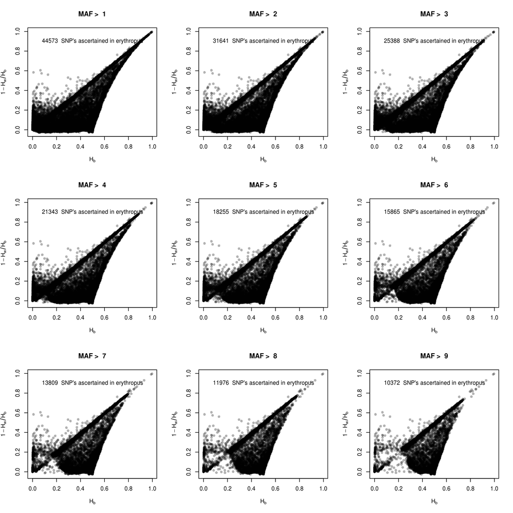

```r
par(mfrow=c(3,3))
for(i in 1:9){
# ascertainment in ery, no singletons
ery.snps = ery.mafs.withFST[ery.mafs.withFST$MAF>i/(2*n),]
nrow(ery.snps)
#
plot(ery.snps$Hb, ery.snps$Hb.minus.Hw/ery.snps$Hb,
     xlab=expression(H[b]),
     ylab=expression(1-H[w]/H[b]),
     pch=16,
     col=gray(level=0, alpha=.3),
     main=paste("MAF > ", i)
    )
text(x=.05, y=.9, labels=paste(nrow(ery.snps), " SNP's ascertained in erythropus"), pos=4)
}
```

### Ascertained in *parallelus*

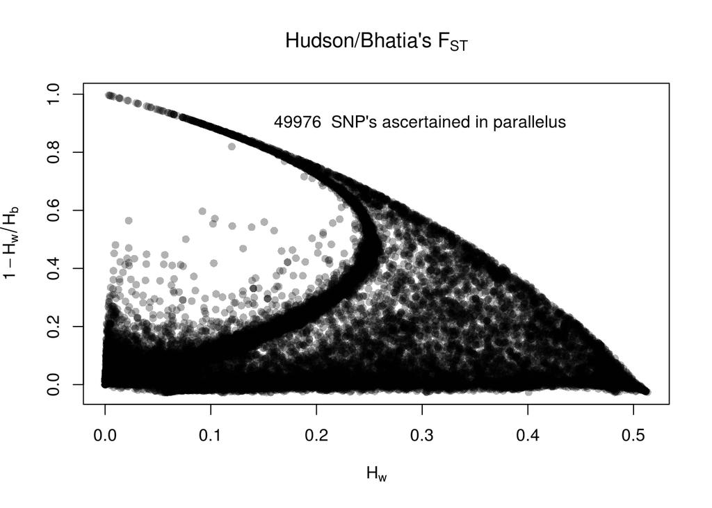

```r
plot(-1*(par.snps$Hb.minus.Hw-par.snps$Hb), par.snps$Hb.minus.Hw/par.snps$Hb,
     xlab=expression(H[w]),
     ylab=expression(1-H[w]/H[b]),
     pch=16,
     col=gray(level=0, alpha=.3),
     main=expression(paste("Hudson/Bhatia's ", F[ST]))
    )
text(x=.15, y=.9, labels=paste(nrow(par.snps), " SNP's ascertained in parallelus"), pos=4)
```

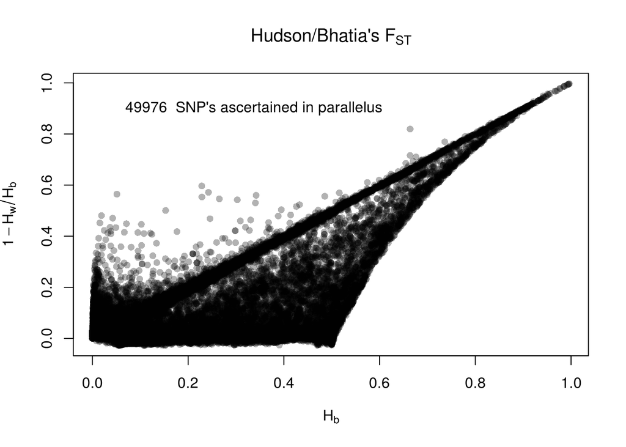

```r
plot(par.snps$Hb, par.snps$Hb.minus.Hw/par.snps$Hb,
     xlab=expression(H[b]),
     ylab=expression(1-H[w]/H[b]),
     pch=16,
     col=gray(level=0, alpha=.3),
     main=expression(paste("Hudson/Bhatia's ", F[ST]))
    )
text(x=.05, y=.9, labels=paste(nrow(par.snps), " SNP's ascertained in parallelus"), pos=4)
```

Not sure what to make of these.

# Folded SAF’s

see this [ngsTools thread](https://groups.google.com/d/topic/ngstools-user/9Z4viLJ7NJA/discussion)

I have also estimated *folded* SAF’s and a folded 2D-SFS and estimated per-site $F_{ST}$ from that.

```r
bhatia = read.delim("EryPar.FOLDED.Bhatia.fst.tab", header=F)
names(bhatia) = c("contig", "pos", "Hb.minus.Hw", "Hb")
reynolds = read.delim("EryPar.FOLDED.Reynolds.fst.tab", header=F)
names(reynolds) = c("contig", "pos", "a", "a.plus.b")
```

```r
( Fst.bhatia.global = sum(bhatia[["Hb.minus.Hw"]])/sum(bhatia[["Hb"]]) )
```

```
## [1] 0.346737
```

```r
nrow(bhatia)
```

```
## [1] 1629161
```

```r
( Fst.reynolds.global = sum(reynolds$a)/sum(reynolds[["a.plus.b"]]) )
```

```
## [1] 0.3654018
```

```r
nrow(reynolds)
```

```
## [1] 1629161
```

```r
Fst.by.contig = aggregate(cbind(Hb.minus.Hw, Hb) ~ contig,
                          data=bhatia,
                          sum
                            )
Fst.by.contig = cbind(Fst.by.contig, FST=Fst.by.contig[,2]/Fst.by.contig[,3])
head(Fst.by.contig)
```

```
##          contig Hb.minus.Hw       Hb         FST
## 1  Contig_10001   -0.007615 0.433124 -0.01758157
## 2 Contig_100013   -0.007615 0.433124 -0.01758157
## 3 Contig_100028    0.249546 1.201124  0.20776040
## 4  Contig_10006    0.834187 1.435808  0.58098785
## 5 Contig_100060    0.083417 0.543252  0.15355121
## 6 Contig_100072    0.006157 0.116979  0.05263338
```

```r
( sum(Fst.by.contig$Hb.minus.Hw)/sum(Fst.by.contig$Hb) )
```

```
## [1] 0.346737
```

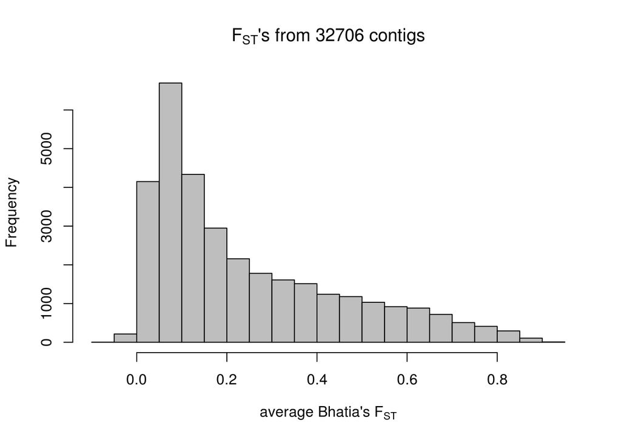

```r
hist(Fst.by.contig$FST, xlab=expression(paste("average Bhatia's ", F[ST])),
     main=bquote(paste(F[ST], "'s from ", .(nrow(Fst.by.contig)), " contigs")),
     col="grey"
     )
```

```r
# proportion of loci with Fst greater than average Fst:
gtAvgFst = sum(Fst.by.contig$FST > Fst.bhatia.global)/length(Fst.by.contig$FST)
```

```r
library(dplyr) # for 'sample_n'
library(parallel) # for 'mclapply'
#
boot = function(x){
  # creates bootstrap resamples of the rows in Fst.by.contig
  # and returns the global Fst from that
  rs = sample_n(Fst.by.contig, size=nrow(Fst.by.contig), replace=TRUE)
  sum(rs$Hb.minus.Hw)/sum(rs$Hb)
  }
#
# serial:
#boot.resample.Fst.by.contig = replicate(10000, boot())
# parallel:
startTime = proc.time()
boot.resample.Fst.by.contig = vector("double", length=10000)
boot.resample.Fst.by.contig= simplify2array(
  mclapply(1:length(boot.resample.Fst.by.contig),
          FUN=boot,
          mc.cores=20
           )
  )
stopTime = proc.time()
elapsedTime = stopTime - startTime
show(elapsedTime)
```

```
##    user  system elapsed
## 496.115   5.617  26.720
```

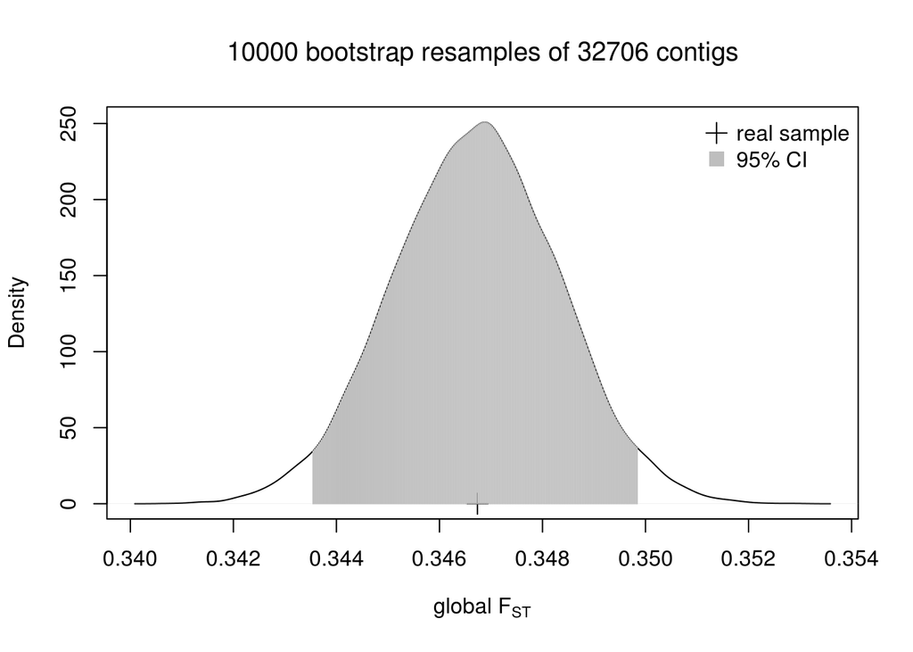

```r
#
d = density(boot.resample.Fst.by.contig)
plot(d,
     xlab=expression(paste("global ", F[ST])),
     main=bquote(paste(.(length(boot.resample.Fst.by.contig)),
                       " bootstrap resamples of ", .(nrow(Fst.by.contig)),
                       " contigs"
                       )
                 )
     )
points(c(Fst.bhatia.global), c(0), pch=3, cex=1.5)
CI95 = quantile(boot.resample.Fst.by.contig, probs=c(.025, .975))
lines(d$x[d$x>CI95[1] & d$x<CI95[2]],
      d$y[d$x>CI95[1] & d$x<CI95[2]],
      type="h",
      col="grey")
legend("topright", legend=c("real sample", "95% CI"), pch=c(3,15), pt.cex=1.5, col=c("black", "grey"), bty="n")
```

### Reynolds

```r
Fst.reynolds.by.contig = aggregate(cbind(a, a.plus.b) ~ contig,
                          data=reynolds,
                          sum
                            )
Fst.reynolds.by.contig = cbind(Fst.reynolds.by.contig, FST=Fst.reynolds.by.contig[,2]/Fst.reynolds.by.contig[,3])
head(Fst.reynolds.by.contig)
```

```
##          contig        a a.plus.b        FST
## 1  Contig_10001 0.004987 0.433124 0.01151402
## 2 Contig_100013 0.004987 0.433124 0.01151402
## 3 Contig_100028 0.276728 1.201124 0.23039087
## 4  Contig_10006 0.851349 1.435808 0.59294070
## 5 Contig_100060 0.096562 0.543252 0.17774808
## 6 Contig_100072 0.009324 0.116979 0.07970661
```

```r
( sum(Fst.reynolds.by.contig$a)/sum(Fst.reynolds.by.contig$a.plus.b) )
```

```
## [1] 0.3654018
```

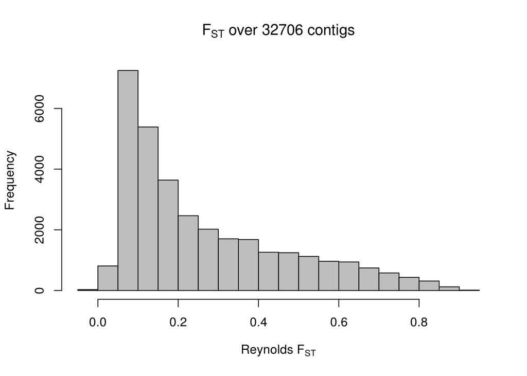

```r
hist(Fst.reynolds.by.contig$FST, xlab=expression(paste("Reynolds ", F[ST])),
     main=bquote(paste(F[ST], " over ", .(nrow(Fst.reynolds.by.contig)), " contigs")),
     col="grey"
     )
```

### 2D-SFS

```r
sfs2d = scan("/data3/claudius/Big_Data/ANGSD/FST/EryPar.FOLDED.2dsfs")
sfs2d = matrix(sfs2d, nrow=19, ncol=19) # rows should be PAR, columns should be ERY
sfs2d[1,1] = 0
```

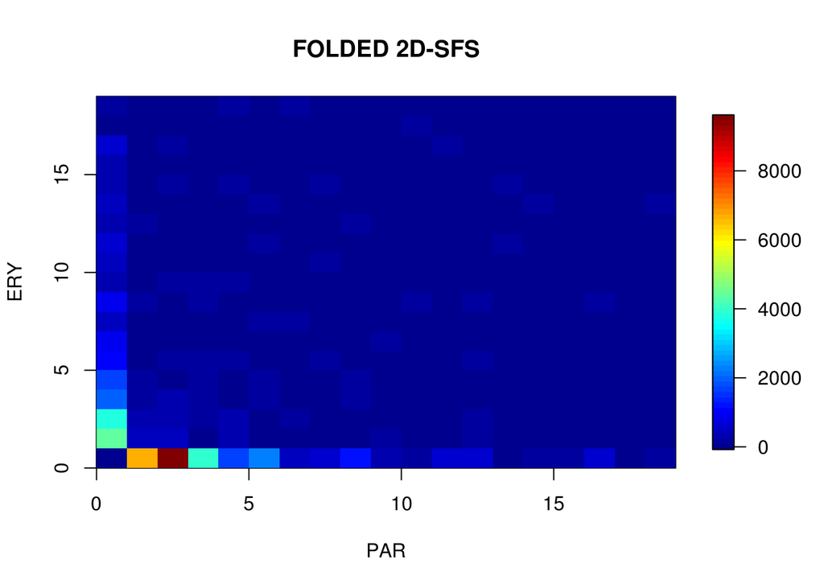

```r
library(fields)
# rows in the matrix are on the x-axis, columns are on the y-axis:
image.plot(0:19, 0:19, sfs2d, xlab="PAR", ylab="ERY", main="FOLDED 2D-SFS")
```

References

Bhatia, Gaurav, Nick Patterson, Sriram Sankararaman, and Alkes L. Price. 2013. “Estimating and Interpreting FST: The Impact of Rare Variants.” *Genome Research* 23 (9): 1514–21. doi:10.1101/gr.154831.113.

Fumagalli, Matteo, Filipe G. Vieira, Thorfinn Sand Korneliussen, Tyler Linderoth, Emilia Huerta-Sánchez, Anders Albrechtsen, and Rasmus Nielsen. 2013. “Quantifying Population Genetic Differentiation from Next-Generation Sequencing Data.” *Genetics* 195 (3). Department of Integrative Biology, University of California, Berkeley, California 94720.: 979–92. doi:10.1534/genetics.113.154740.